# Diagnóstico do modelo linear — roteiro computacional

Autor

Jonathan Vargas Silva

Este roteiro acompanha a execução dos códigos da Aula 7. Execute os blocos na ordem apresentada.

# Representação matricial e MQO

Estime o modelo com `gpa1` e examine a matriz construída pelo R.

```r
# Estima o modelo usado na representação matricial.
modelo <- lm(colGPA ~ hsGPA + ACT, data = gpa1)

# Extrai a matriz do modelo construída a partir da fórmula.
X <- model.matrix(modelo)

head(X, 5)
```

```
  (Intercept) hsGPA ACT
1           1   3.0  21
2           1   3.2  24
3           1   3.6  26
4           1   3.5  27
5           1   3.9  28
```

Calcule os coeficientes diretamente pela expressão matricial do MQO.

```r
# Define o vetor da variável dependente.
y <- gpa1$colGPA

# Calcula X'X e X'y.
XtX <- t(X) %*% X
Xty <- t(X) %*% y

# Calcula os coeficientes pela expressão matricial do MQO.
beta_formula <- solve(XtX) %*% Xty
beta_formula
```

```
                   [,1]
(Intercept) 1.286327767
hsGPA       0.453455885
ACT         0.009426012
```

Repita o cálculo com `crossprod()`.

```r
# Calcula os coeficientes usando produtos cruzados.
beta_crossprod <- solve(crossprod(X)) %*% crossprod(X, y)
beta_crossprod
```

```
                   [,1]
(Intercept) 1.286327767
hsGPA       0.453455885
ACT         0.009426012
```

Compare o condicionamento de $\mathbf{X}$ e de $\mathbf{X}^{\mathsf T}\mathbf{X}$.

```r
# Calcula os números de condição com base nos valores singulares.
kappa_X <- kappa(X, exact = TRUE)
kappa_XtX <- kappa(crossprod(X), exact = TRUE)

kappa_X
```

```
[1] 298.0027
```

```r
kappa_XtX
```

```
[1] 88805.62
```

```r
kappa_X^2
```

```
[1] 88805.62
```

Obtenha os coeficientes pela decomposição QR e compare-os com `lm()`.

```r
# Calcula a decomposição QR e obtém os coeficientes de MQO.
qr_X <- qr(X)
beta_qr <- qr.coef(qr_X, y)

cbind(
  `QR explícita` = beta_qr,
  `lm()` = coef(modelo)
)
```

```
            QR explícita        lm()
(Intercept)  1.286327767 1.286327767
hsGPA        0.453455885 0.453455885
ACT          0.009426012 0.009426012
```

# Multicolinearidade

Use as observações de 1994 de `rice5` para estimar a função de produção.

```r
# Mantém apenas as observações de 1994.
rice_1994 <- rice5 |>
  filter(year == 1994)

# Estima a função de produção.
modelo_arroz <- lm(
  log(prod) ~ log(area) + log(labor) + log(fert),
  data = rice_1994
)

# Exibe os resultados e o coeficiente de determinação.
broom::tidy(modelo_arroz)
```

```
# A tibble: 4 × 5
  term        estimate std.error statistic p.value
  <chr>          <dbl>     <dbl>     <dbl>   <dbl>
1 (Intercept)   -1.95      0.738     -2.64  0.0119
2 log(area)      0.211     0.182      1.16  0.254
3 log(labor)     0.378     0.255      1.48  0.147
4 log(fert)      0.343     0.128      2.68  0.0106
```

```r
broom::glance(modelo_arroz) |>
  select(r.squared)
```

```
# A tibble: 1 × 1
  r.squared
      <dbl>
1     0.875
```

Estime a regressão auxiliar para `labor` e calcule seu VIF manualmente.

```r
# Estima a regressão auxiliar para log(labor).
aux_labor <- lm(
  log(labor) ~ log(area) + log(fert),
  data = rice_1994
)

# Recupera o R² auxiliar e calcula o VIF.
r2_labor <- broom::glance(aux_labor)$r.squared
vif_labor <- 1 / (1 - r2_labor)

r2_labor
```

```
[1] 0.9436107
```

```r
vif_labor
```

```
[1] 17.73385
```

Calcule os VIFs das três regressoras.

```r
# Calcula os VIFs do modelo completo.
car::vif(modelo_arroz)
```

```
 log(area) log(labor)  log(fert)
  9.149377  17.733853   7.683995
```

Compare a evidência individual com o teste conjunto para `area` e `labor`.

```r
# Testa conjuntamente os coeficientes de log(area) e log(labor).
car::linearHypothesis(
  modelo_arroz,
  c(
    "log(area) = 0",
    "log(labor) = 0"
  )
)
```

```
Linear hypothesis test:
log(area) = 0
log(labor) = 0

Model 1: restricted model
Model 2: log(prod) ~ log(area) + log(labor) + log(fert)

  Res.Df    RSS Df Sum of Sq      F   Pr(>F)
1     42 5.3357
2     40 3.9245  2    1.4112 7.1918 0.002147 **
---
Signif. codes:  0 '***' 0.001 '**' 0.01 '*' 0.05 '.' 0.1 ' ' 1
```

# Multicolinearidade e especificação do modelo

Compare o coeficiente da educação antes e depois da inclusão de `score` como proxy para habilidade.

```r
# Estima o modelo sem a proxy para habilidade.
modelo_sem_score <- lm(
  log(wage) ~ educ + exper + I(exper^2),
  data = koop_tobias_87
)

# Inclui o escore de aptidão como proxy para habilidade.
modelo_com_score <- lm(
  log(wage) ~ educ + exper + I(exper^2) + score,
  data = koop_tobias_87
)

# Compara os coeficientes estimados para educação.
round(coef(modelo_sem_score)["educ"], 4)
```

```
  educ
0.0728
```

```r
round(coef(modelo_com_score)["educ"], 4)
```

```
  educ
0.0592
```

# Diagnósticos gráficos dos resíduos

Simule uma relação quadrática e compare os resíduos de duas especificações.

```r
# Torna a simulação reprodutível.
set.seed(123)

# Simula dados segundo uma média condicional quadrática.
n <- 200
x <- runif(n, -3, 3)
erro <- rnorm(n)
y <- 1 + x + x^2 + erro
dados_forma <- data.frame(x = x, y = y)

# Estima os modelos sem e com o termo quadrático.
modelo_linear <- lm(y ~ x, data = dados_forma)
modelo_quadratico <- lm(y ~ x + I(x^2), data = dados_forma)
```

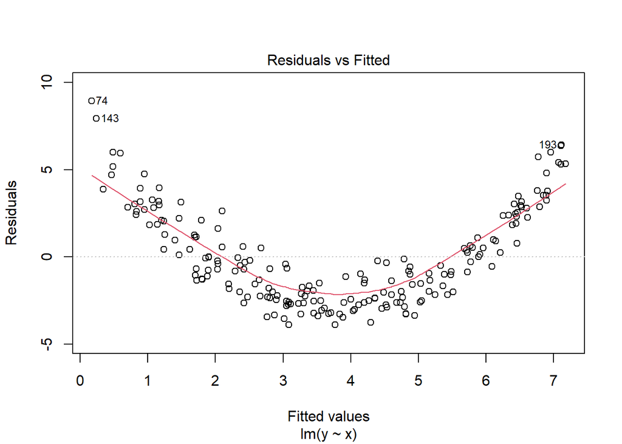

```r
# Compara os diagnósticos das duas especificações.
plot(modelo_linear, which = 1)
```

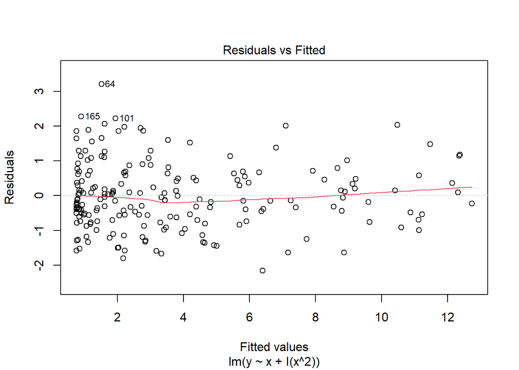

```r
plot(modelo_quadratico, which = 1)
```

**Observe:** acompanhe como a curvatura dos resíduos se modifica quando o termo quadrático é incluído.

Simule uma relação cúbica e repita o diagnóstico.

```r
# Torna a simulação reprodutível.
set.seed(789)

# Simula dados segundo uma média condicional cúbica.
n_cubico <- 200
x_cubico <- runif(n_cubico, -2, 2)
erro_cubico <- rnorm(n_cubico, mean = 0, sd = 0.6)
y_cubico <- 1 + x_cubico + x_cubico^3 + erro_cubico
dados_cubico <- data.frame(x = x_cubico, y = y_cubico)

# Estima os modelos sem e com o termo cúbico.
modelo_cubico_linear <- lm(y ~ x, data = dados_cubico)
modelo_cubico <- lm(y ~ x + I(x^3), data = dados_cubico)
```

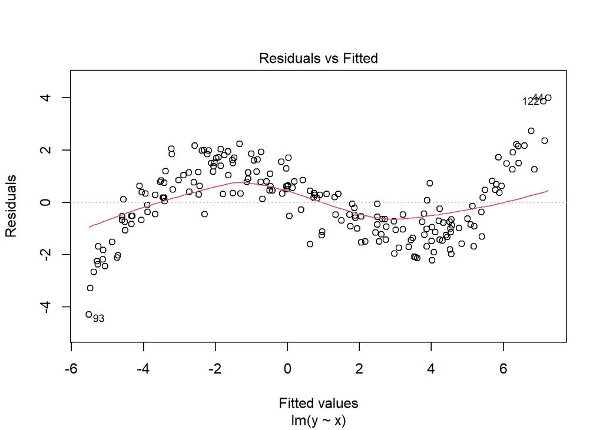

```r
# Compara os diagnósticos das duas especificações.
plot(modelo_cubico_linear, which = 1)
```

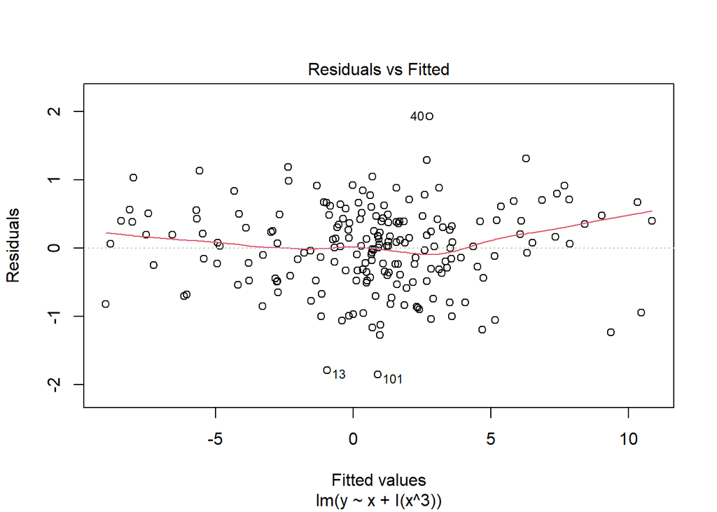

```r
plot(modelo_cubico, which = 1)
```

**Observe:** compare a estrutura dos resíduos antes e depois de representar a forma cúbica da média condicional.

# Normalidade dos erros: papel na inferência e diagnóstico

Estime o modelo com `PublicSchools` e obtenha os resíduos padronizados.

```r
# Mantém somente as observações completas.
ps <- na.omit(PublicSchools)

# Estima o modelo usado no diagnóstico de normalidade.
ps_lm <- lm(Expenditure ~ Income, data = ps)

# Calcula os resíduos padronizados.
ps_lm_residuos_pad <- rstandard(ps_lm)
```

Produza os dois gráficos Q-Q utilizados na aula.

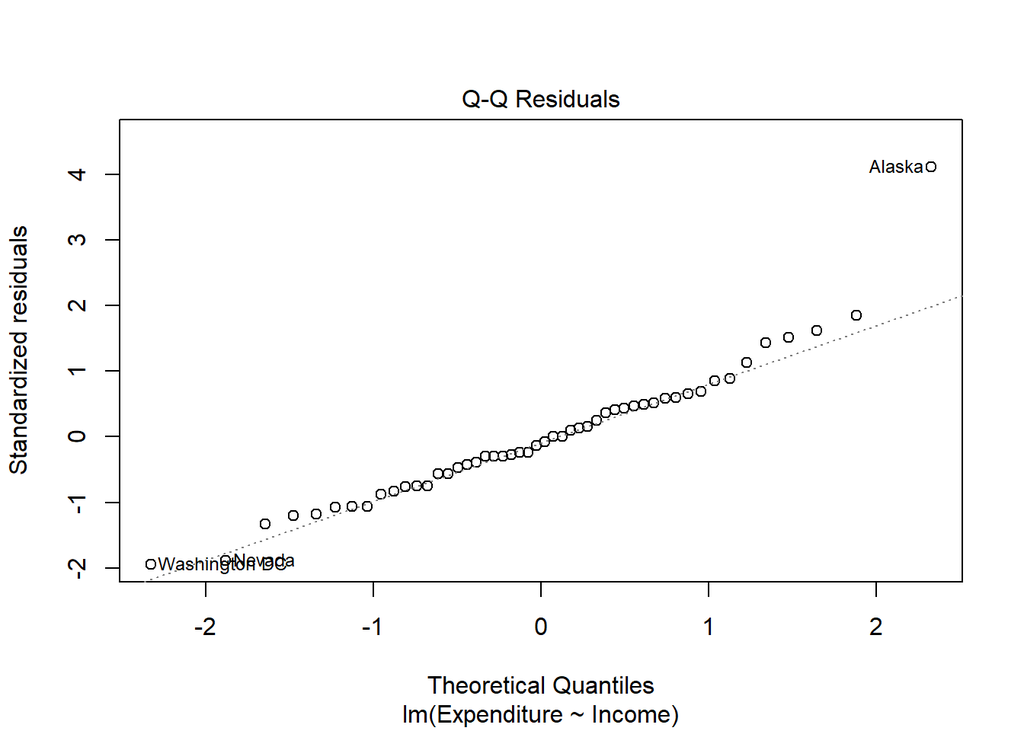

```r
# Produz o gráfico Normal Q-Q de diagnóstico do modelo.
plot(ps_lm, which = 2)
```

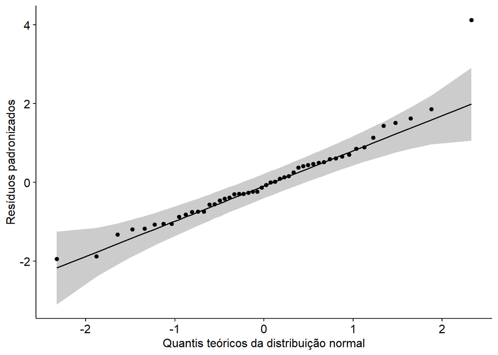

```r
# Produz o Q-Q dos resíduos padronizados com faixa de confiança.
ggpubr::ggqqplot(ps_lm_residuos_pad) +
  xlab("Quantis teóricos da distribuição normal") +
  ylab("Resíduos padronizados")
```

Aplique os testes de normalidade apresentados nos slides.

```r
# Extrai os resíduos do modelo.
ps_lm_residuos <- residuals(ps_lm)

# Aplica o teste de Shapiro-Wilk.
shapiro.test(ps_lm_residuos)
```

```
    Shapiro-Wilk normality test

data:  ps_lm_residuos
W = 0.94814, p-value = 0.02863
```

```r
# Aplica o teste clássico de Jarque-Bera.
DescTools::JarqueBeraTest(
  ps_lm_residuos,
  robust = FALSE,
  method = "chisq"
)
```

```
    Jarque Bera Test

data:  ps_lm_residuos
X-squared = 18.178, df = 2, p-value = 0.0001129
```